# k-Means Clustering

### Sam Freund

Here we will explore a class of unsupervised machine learning models: clustering algorithms. Clustering algorithms seek to learn, from the properties of the data, an optimal division or discrete labeling of groups of points.

Many clustering algorithms are available in Scikit-Learn and elsewhere, but perhaps the simplest to understand is an algorithm known as *k-means clustering*, which is implemented in `sklearn.cluster.KMeans`.

We begin with some imports:

```python
%matplotlib inline
import matplotlib.pyplot as plt
import seaborn as sns; sns.set()  # for plot styling
import numpy as np
import pandas as pd
from sklearn.cluster import KMeans
from scipy.spatial.distance import cdist
import itertools
from sklearn.metrics import silhouette_score, silhouette_samples, davies_bouldin_score
from sklearn import preprocessing
from sklearn.decomposition import PCA
```

## Excercise 1:

Import the Candy data and show the first 10 rows. Write a dataset description based on the information provided.

```python
candy = pd.read_csv("/data/cs2300/L5/candy-data.csv")#again, you should put the path on your machine here
candy.head()
```

|  | competitorname | chocolate | fruity | caramel | peanutyalmondy | nougat | crispedricewafer | hard | bar | pluribus | sugarpercent | pricepercent | winpercent |
| --- | --- | --- | --- | --- | --- | --- | --- | --- | --- | --- | --- | --- | --- |
| 0 | Tootsie Roll Midgies | 1 | 0 | 0 | 0 | 0 | 0 | 0 | 0 | 1 | 0.174 | 0.011 | 45.736748 |
| 1 | Pixie Sticks | 0 | 0 | 0 | 0 | 0 | 0 | 0 | 0 | 1 | 0.093 | 0.023 | 37.722336 |
| 2 | Dum Dums | 0 | 1 | 0 | 0 | 0 | 0 | 1 | 0 | 0 | 0.732 | 0.034 | 39.460556 |
| 3 | Fruit Chews | 0 | 1 | 0 | 0 | 0 | 0 | 0 | 0 | 1 | 0.127 | 0.034 | 43.088924 |
| 4 | Strawberry bon bons | 0 | 1 | 0 | 0 | 0 | 0 | 1 | 0 | 1 | 0.569 | 0.058 | 34.578991 |

## Dataset Description

The dataset contains a list of candies which have been compared against each other. It contains characteristics of each candy, and most importantly the percentage of times that, when compared against another candy, it won the comparison.

## Exercise 2:

Create a scatter plot comparing the price percent and win percent. Write a few sentences in the reflection below that describes what you observe (are there any obvious groups?).

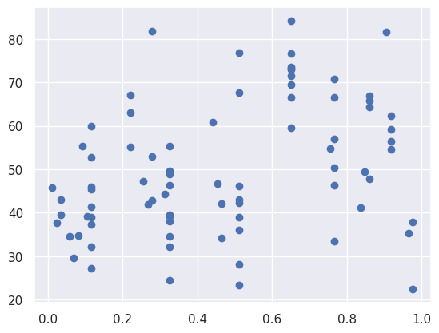

```python
plt.scatter(candy["pricepercent"], candy["winpercent"])
plt.show()
```

## Exercise 3:

In the following cell, convert the dataframe into a 2D numpy array called X that only contains numerical data (by dropping the one categorical column "competitorname" - this column does not contain relevant info for clustering).

```python
candy = candy.drop(columns="competitorname")

X = candy.to_numpy()
```

The following code will create a kMeans classifier using the data in `X`. Run this cell, and feel free to come back to experiment with different values of k. You should not need to modify this cell if you completed the previous cell as expected.

```python
kmeans = KMeans(n_clusters=2)
kmeans.fit(X)
y_kmeans = kmeans.predict(X)
```

Let's visualize the results by plotting the data colored by these labels using the columns `pricepercent` and `winpercent`. We will also plot the cluster centers in yellow as determined by the *k*-means estimator:

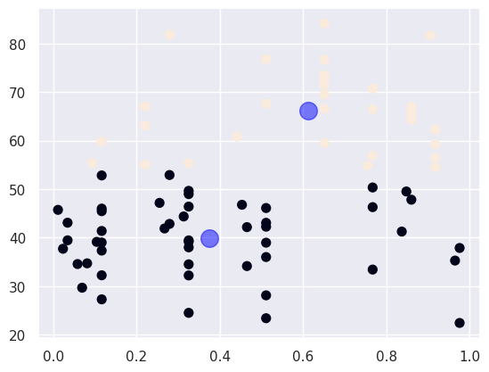

```python
plt.scatter(X[:, 10], X[:, 11], c=y_kmeans, s=50)

centers = kmeans.cluster_centers_
plt.scatter(centers[:, 10], centers[:, 11], c='blue', s=200, alpha=0.5);
```

## Exercise 4:

This clustering isn't necessarily what you would expect, right? This is most likely due to scaling bias in the distance calculation. To address this, we need to scale the axes. In the following cell, scale values using sklearn.preprocessing.scale(). You should re-do the clustering and plot the results to compare them to what you generated earlier.

**Note: All further clustering should be done on the scaled data**

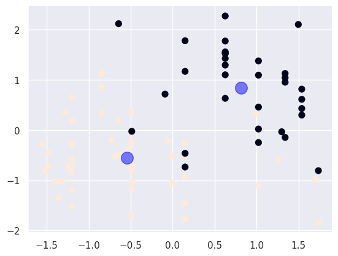

```python
X = preprocessing.scale(X)

kmeans = KMeans(n_clusters=2)
kmeans.fit(X)
y_kmeans = kmeans.predict(X)

plt.scatter(X[:, 10], X[:, 11], c=y_kmeans, s=50)

centers = kmeans.cluster_centers_
plt.scatter(centers[:, 10], centers[:, 11], c='blue', s=200, alpha=0.5);
```

### Reflection:

How do these results compare with your unscaled results? They seem to be more accurate, with the upper left points specifically shifting to a different cluster.

## Exercise 5:

Try (and display graphs of) three additional k values to see how KMeans clusters the data. Additionally, apply Principal Components Analysis (PCA) to give a "good" view of your 11-dimensional data in 2 dimensions (see the unsupervised learning notebook from lecture for an exmample on how to do this). Document your experiments and write a short description in the reflection section below - which set of k-means clusters appeared to give the most distinct separation between groups?

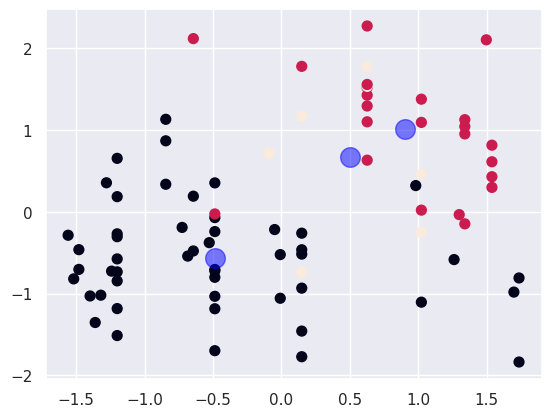

```python
kmeans = KMeans(n_clusters=3)
kmeans.fit(X)
y_kmeans = kmeans.predict(X)

plt.scatter(X[:, 10], X[:, 11], c=y_kmeans, s=50)

centers = kmeans.cluster_centers_
plt.scatter(centers[:, 10], centers[:, 11], c='blue', s=200, alpha=0.5);
```

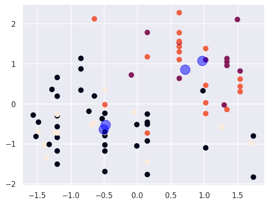

```python
kmeans = KMeans(n_clusters=4)
kmeans.fit(X)
y_kmeans = kmeans.predict(X)

plt.scatter(X[:, 10], X[:, 11], c=y_kmeans, s=50)

centers = kmeans.cluster_centers_
plt.scatter(centers[:, 10], centers[:, 11], c='blue', s=200, alpha=0.5);
```

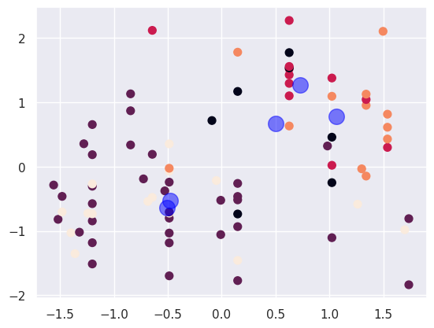

```python
kmeans = KMeans(n_clusters=5)
kmeans.fit(X)
y_kmeans = kmeans.predict(X)

plt.scatter(X[:, 10], X[:, 11], c=y_kmeans, s=50)

centers = kmeans.cluster_centers_
plt.scatter(centers[:, 10], centers[:, 11], c='blue', s=200, alpha=0.5);
```

### Reflection

All of these seem rather convoluted, with a lot of centers being located very close to each other. This makes me think that the 'k' value of 2 is optimal for this situation.

## Excercise 6:

One way discussed in class to evaluate how "good" one group of clusters is is to compare the Davies-Bouldin score. Compute and display the Davies-Bouldin score for the 4 values of 'k' that you used above. Be sure to clearly label which output values belong to which graphs.

Does the 'k' that the Davies Bouldin score denotes as creating the best clusters align with your "eye-balled" analysis from Exercise 5? If not, why might this be?

```
Best k by Davies-Bouldin: 2 (DB=1.4376)
```

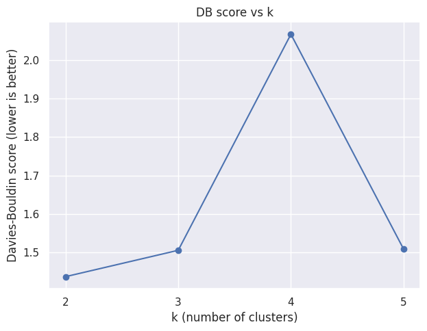

```python
db_scores = []
ks = range(2,6)
for i in ks:
    kmeans = KMeans(n_clusters=i)
    labels = kmeans.fit_predict(X)
    db_scores.append(davies_bouldin_score(X, labels))

# pick best k (lowest Davies-Bouldin)
best_score = min(db_scores)
best_k = list(ks)[db_scores.index(best_score)]
print(f"Best k by Davies-Bouldin: {best_k} (DB={best_score:.4f})")

# fit final model with best_k
final_km = KMeans(n_clusters=best_k, random_state=42)
final_labels = final_km.fit_predict(X)

# plot DB vs k and PCA scatter colored by chosen clusters
plt.figure(figsize=(12,5))

plt.subplot(1,2,1)
plt.plot(list(ks), db_scores, marker='o')
plt.xticks(list(ks))
plt.xlabel("k (number of clusters)")
plt.ylabel("Davies-Bouldin score (lower is better)")
plt.title("DB score vs k")

plt.tight_layout()
```

## Exercise 7

Another way to evaluate which number of clusters is best is to use the "within cluster sum of squares" or inertia. It is a measure of how coherent the clusters are. We can look at a variety of k-values to see how the inertia changes for different k-values. This is not a perfect measure (it is subject to several types of biases), but it can be used to compare different k-values.

To use the "Elbow Method" you want to find an "elbow" where there is a distinct change in the plot of different k-values. It is not always very obvious, but this describes what to look for: https://www.geeksforgeeks.org/elbow-method-for-optimal-value-of-k-in-kmeans/

Calculate the "inertia" for k-means clusters with k varying between 2 and 6 and display and "elbow plot". Using the "elbow" method, which number of clusters would you say is best? Why? (put answer in reflection below).

Note that for each clustering object you create, it has an attribute called "inertia_" that represents this value.

```
Inertia values:
1 : 960.0
2 : 659.1256292637731
3 : 620.7617551825069
4 : 551.2309474209638
5 : 487.43384181244556
6 : 436.76982882210757
```

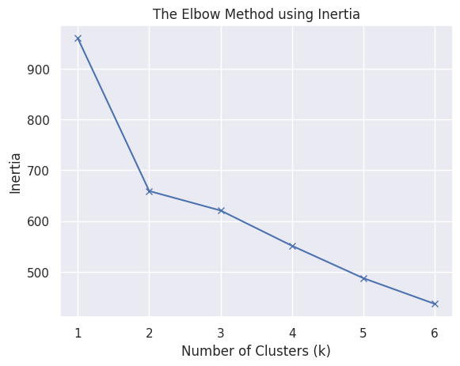

```python
distortions = []
inertias = []
mapping1 = {}
mapping2 = {}
ks = range(1, 7)

for i in ks:
    kmeanModel = KMeans(n_clusters=i, random_state=42).fit(X)

    distortions.append(sum(np.min(cdist(X, kmeanModel.cluster_centers_, 'euclidean'), axis=1)**2) / X.shape[0])

    inertias.append(kmeanModel.inertia_)

    mapping1[i] = distortions[-1]
    mapping2[i] = inertias[-1]

print("Inertia values:")
for key, val in mapping2.items():
    print(f'{key} : {val}')

plt.plot(ks, inertias, 'bx-')
plt.xlabel('Number of Clusters (k)')
plt.ylabel('Inertia')
plt.title('The Elbow Method using Inertia')
plt.show()
```

## Reflection

Utilizing the elbow method, it would appear that 2 is our elbow point, as we find a large inflection located there.

## Exercise 8

A third metric used to help identify how many clusters you should have is called the Silhouette Coefficient. You can read up on it in the following locations: https://scikit-learn.org/stable/modules/generated/sklearn.metrics.silhouette_score.html and https://towardsdatascience.com/silhouette-coefficient-validating-clustering-techniques-e976bb81d10c.

Calculate and display the Silhouette Coefficient for k-means clusters with k varying between 2 and 6. Which k-value does the Silhouette Coefficient claim creates the best clusters?

**Answer here:**

Utilizing the silhouette coefficient, the best 'k' would seem to be 2, as this has the silhouette score closest to 1.

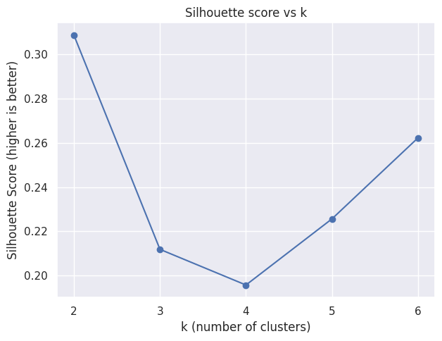

```python
db_scores = []
ks = range(2,7)
for i in ks:
    kmeans = KMeans(n_clusters=i)
    labels = kmeans.fit_predict(X)
    db_scores.append(silhouette_score(X, labels))

# fit final model with best_k
final_km = KMeans(n_clusters=best_k, random_state=42)
final_labels = final_km.fit_predict(X)

# plot DB vs k and PCA scatter colored by chosen clusters
plt.figure(figsize=(12,5))

plt.subplot(1,2,1)
plt.plot(list(ks), db_scores, marker='o')
plt.xticks(list(ks))
plt.xlabel("k (number of clusters)")
plt.ylabel("Silhouette Score (higher is better)")
plt.title("Silhouette score vs k")

plt.tight_layout()
```

# Example: k-means on images

To start, let's take a look at applying *k*-means on simple handwritten digits images. Here we will attempt to use *k*-means to try to identify similar digits *without using the original label information*. We will start by loading the digits and then finding the `KMeans` clusters.

The digits data consist of 1,797 samples with 64 features, where each of the 64 features is the brightness of one pixel in an 8×8 image. We start by loading the data

```python
from sklearn.datasets import load_digits
digits = load_digits()
```

Let's take a look at one of the images.

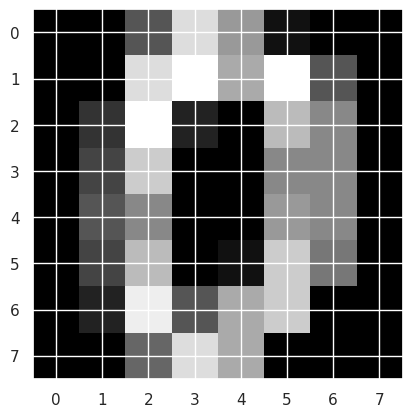

```python
plt.imshow(digits.images[0], cmap='gray')
plt.show()
```

## Exercise 9:

Write a few lines of code to create a KMeans model using `digits.data` and 10 clusters. No need to plot, just create the clusters for now. Note that you should name your model object `kmeans` and the assigned clusters to `clusters` so that the following code cells will run appropriately.

```python
kmeans = KMeans(n_clusters=10)
kmeans.fit(digits.data)
y_kmeans = kmeans.predict(digits.data)

clusters = kmeans.labels_
```

Let's see what the cluster centers look like:

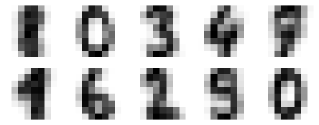

```python
fig, ax = plt.subplots(2, 5, figsize=(8, 3))
centers = kmeans.cluster_centers_.reshape(10, 8, 8)
for axi, center in zip(ax.flat, centers):
    axi.set(xticks=[], yticks=[])
    axi.imshow(center, interpolation='nearest', cmap=plt.cm.binary)
```

*k*-means knows nothing about the identity of the cluster, so the clusters are not in any specific order. To identify the actual order, we can use the labels in the following code.

```python
from scipy.stats import mode

labels = np.zeros_like(clusters)
for i in range(10):
    mask = (clusters == i) #array of booleans for each cluster group
    labels[mask] = mode(digits.target[mask])[0] #get "mode" of each cluster group's label
```

Now we can check how accurate our unsupervised clustering was in finding similar digits within the data:

```python
from sklearn.metrics import accuracy_score
accuracy_score(digits.target, labels)
```

```
0.7145242070116862
```

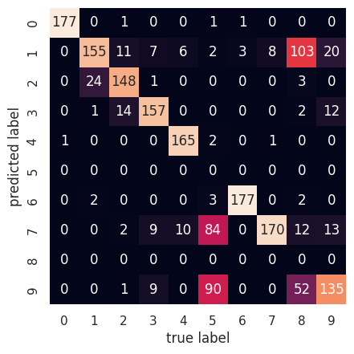

```python
from sklearn.metrics import confusion_matrix
mat = confusion_matrix(digits.target, labels)
sns.heatmap(mat.T, square=True, annot=True, fmt='d', cbar=False,
            xticklabels=digits.target_names,
            yticklabels=digits.target_names)
plt.xlabel('true label')
plt.ylabel('predicted label')
```

As we might expect from the cluster centers we visualized before, the main point of confusion is between the eights and ones. But this still shows that using *k*-means, we can essentially build a digit classifier *without reference to any known labels*!

## Exercise 10:

Let's try this with higher resolution images! Use the code below to import the 28x28 DIGITS images. Note, you will either need to be on Rosie's Tensorflow 2.x container, or you will likely need to install some libraries locally.

Then complete the following steps:

1. Plot an example image
2. Train a KMeans cluster using the testing data. Note that you will need to reshape the data to be in the correct format. Note that the N images will result in an N x 28 x 28 array. You will need to reshape the data to be an N x (28*28) array. Look into the numpy .reshape() method to accomplish this.
3. Plot the cluster centers
4. Calculate the accuracy
5. Plot the confusion matrix
6. Use the training data and re-run the experiment to see how sensitive the model is to the data.
7. Write a short reflection on what you observed from this and why it might be the case.

```python
import tensorflow as tf
from tensorflow import keras
(X_train, y_train), (X_test, y_test) = tf.keras.datasets.mnist.load_data()
```

[output not shown]

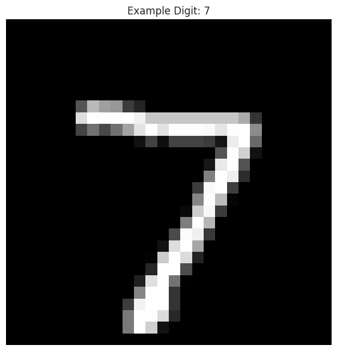

```
============================================================
STEP 2: Training KMeans on Testing Data
============================================================
Reshaped test data: (10000, 784)
Training KMeans (this may take a minute)...
KMeans training complete!
Inertia: 389394.97

============================================================
STEP 3: Plotting Cluster Centers
============================================================
```

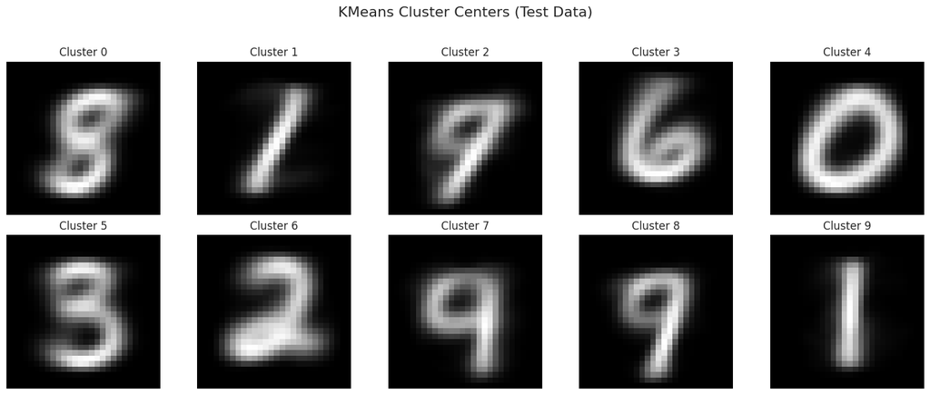

```
============================================================
STEP 4: Calculating Accuracy
============================================================
Cluster to Label Mapping: {0: 8, 1: 1, 2: 7, 3: 6, 4: 0, 5: 3, 6: 2, 7: 4, 8: 7, 9: 1}

Accuracy on Test Data: 58.87%

============================================================
STEP 5: Plotting Confusion Matrix
============================================================
```

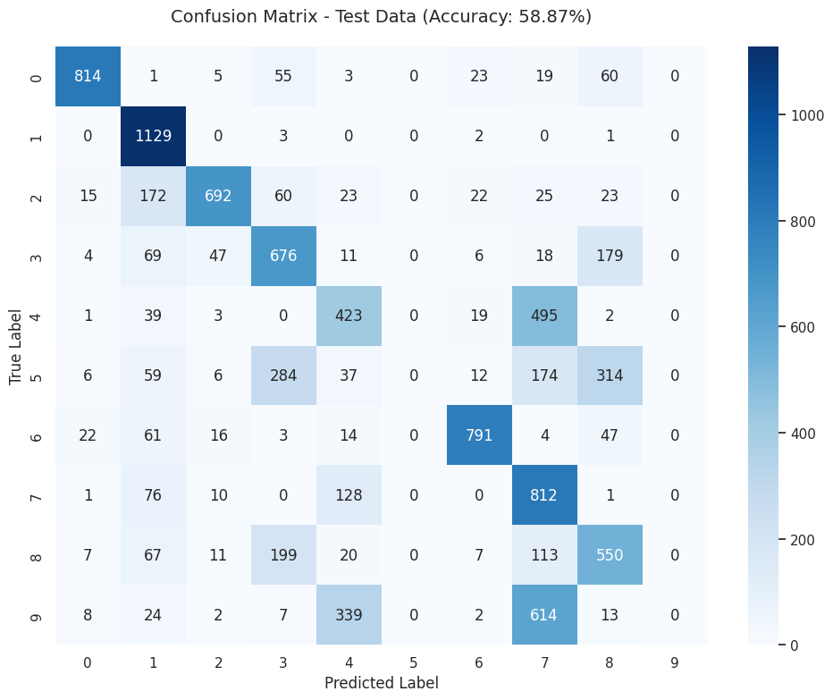

```
============================================================
STEP 6: Re-running Experiment with Training Data
============================================================
Reshaped training data: (60000, 784)
Training KMeans on training data (this will take longer)...
KMeans training complete!
Inertia: 2352826.63
```

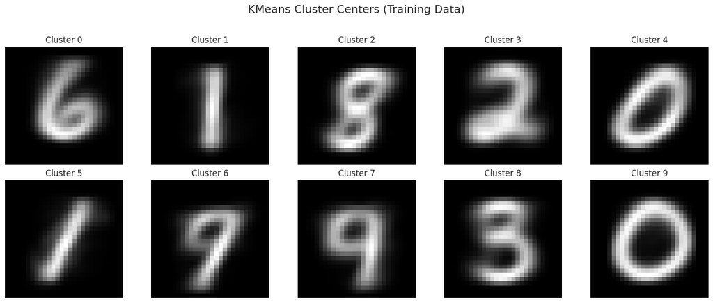

```
Cluster to Label Mapping: {0: 6, 1: 1, 2: 8, 3: 2, 4: 0, 5: 1, 6: 7, 7: 4, 8: 3, 9: 0}

Accuracy on Training Data: 59.08%
```

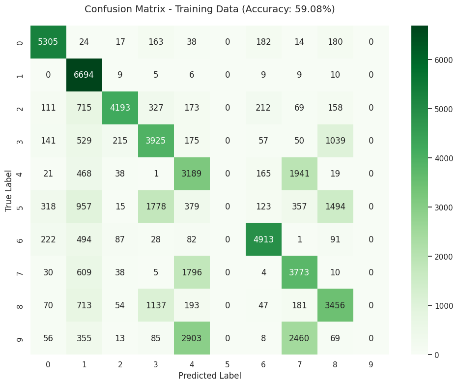

```
============================================================
STEP 7: Analysis Summary
============================================================

Test Data Results:
  - Accuracy: 58.87%
  - Inertia: 389394.97
  - Dataset size: 10000 images

Training Data Results:
  - Accuracy: 59.08%
  - Inertia: 2352826.63
  - Dataset size: 60000 images

Difference in accuracy: 0.21 percentage points

============================================================
```

```python
# ==================== STEP 1: Plot an example image ====================
plt.figure(figsize=(6, 6))
plt.imshow(X_test[0], cmap='gray')
plt.title(f'Example Digit: {y_test[0]}')
plt.axis('off')
plt.tight_layout()
plt.savefig('example_digit.png', dpi=150, bbox_inches='tight')
plt.show()

# ==================== STEP 2: Train KMeans on testing data ====================
print("\n" + "="*60)
print("STEP 2: Training KMeans on Testing Data")
print("="*60)

# Reshape test data from (N, 28, 28) to (N, 784)
X_test_flat = X_test.reshape(X_test.shape[0], -1)
print(f"Reshaped test data: {X_test_flat.shape}")

# Normalize pixel values to [0, 1]
X_test_normalized = X_test_flat / 255.0

# Train KMeans with 10 clusters (one for each digit)
print("Training KMeans (this may take a minute)...")
kmeans_test = KMeans(n_clusters=10, random_state=42, n_init=10, max_iter=300)
kmeans_test.fit(X_test_normalized)
y_pred_test = kmeans_test.labels_

print(f"KMeans training complete!")
print(f"Inertia: {kmeans_test.inertia_:.2f}")

# ==================== STEP 3: Plot the cluster centers ====================
print("\n" + "="*60)
print("STEP 3: Plotting Cluster Centers")
print("="*60)

cluster_centers = kmeans_test.cluster_centers_.reshape(10, 28, 28)

fig, axes = plt.subplots(2, 5, figsize=(15, 6))
for i, ax in enumerate(axes.flat):
    ax.imshow(cluster_centers[i], cmap='gray')
    ax.set_title(f'Cluster {i}')
    ax.axis('off')
plt.suptitle('KMeans Cluster Centers (Test Data)', fontsize=16, y=1.02)
plt.tight_layout()
plt.savefig('cluster_centers_test.png', dpi=150, bbox_inches='tight')
plt.show()

# ==================== STEP 4: Calculate accuracy ====================
print("\n" + "="*60)
print("STEP 4: Calculating Accuracy")
print("="*60)

# Map clusters to labels by finding the most common true label in each cluster
def map_clusters_to_labels(y_true, y_pred):
    """Map cluster IDs to actual labels based on majority voting"""
    cluster_to_label = {}
    for cluster_id in range(10):
        mask = (y_pred == cluster_id)
        if mask.sum() > 0:
            # Find most common label in this cluster
            labels_in_cluster = y_true[mask]
            most_common = np.bincount(labels_in_cluster).argmax()
            cluster_to_label[cluster_id] = most_common
    return cluster_to_label

# Create mapping and apply it
cluster_mapping_test = map_clusters_to_labels(y_test, y_pred_test)
print(f"Cluster to Label Mapping: {cluster_mapping_test}")

# Convert predicted clusters to predicted labels
y_pred_labels_test = np.array([cluster_mapping_test[cluster] for cluster in y_pred_test])

# Calculate accuracy
accuracy_test = accuracy_score(y_test, y_pred_labels_test)
print(f"\nAccuracy on Test Data: {accuracy_test*100:.2f}%")

# ==================== STEP 5: Plot confusion matrix ====================
print("\n" + "="*60)
print("STEP 5: Plotting Confusion Matrix")
print("="*60)

cm_test = confusion_matrix(y_test, y_pred_labels_test)

plt.figure(figsize=(10, 8))
sns.heatmap(cm_test, annot=True, fmt='d', cmap='Blues',
            xticklabels=range(10), yticklabels=range(10))
plt.title(f'Confusion Matrix - Test Data (Accuracy: {accuracy_test*100:.2f}%)',
          fontsize=14, pad=20)
plt.ylabel('True Label', fontsize=12)
plt.xlabel('Predicted Label', fontsize=12)
plt.tight_layout()
plt.savefig('confusion_matrix_test.png', dpi=150, bbox_inches='tight')
plt.show()

# ==================== STEP 6: Re-run with training data ====================
print("\n" + "="*60)
print("STEP 6: Re-running Experiment with Training Data")
print("="*60)

# Reshape and normalize training data
X_train_flat = X_train.reshape(X_train.shape[0], -1)
X_train_normalized = X_train_flat / 255.0
print(f"Reshaped training data: {X_train_flat.shape}")

# Train KMeans on training data
print("Training KMeans on training data (this will take longer)...")
kmeans_train = KMeans(n_clusters=10, random_state=42, n_init=10, max_iter=300)
kmeans_train.fit(X_train_normalized)
y_pred_train = kmeans_train.labels_

print(f"KMeans training complete!")
print(f"Inertia: {kmeans_train.inertia_:.2f}")

# Plot cluster centers for training data
cluster_centers_train = kmeans_train.cluster_centers_.reshape(10, 28, 28)

fig, axes = plt.subplots(2, 5, figsize=(15, 6))
for i, ax in enumerate(axes.flat):
    ax.imshow(cluster_centers_train[i], cmap='gray')
    ax.set_title(f'Cluster {i}')
    ax.axis('off')
plt.suptitle('KMeans Cluster Centers (Training Data)', fontsize=16, y=1.02)
plt.tight_layout()
plt.savefig('cluster_centers_train.png', dpi=150, bbox_inches='tight')
plt.show()

# Calculate accuracy for training data
cluster_mapping_train = map_clusters_to_labels(y_train, y_pred_train)
print(f"Cluster to Label Mapping: {cluster_mapping_train}")

y_pred_labels_train = np.array([cluster_mapping_train[cluster] for cluster in y_pred_train])
accuracy_train = accuracy_score(y_train, y_pred_labels_train)
print(f"\nAccuracy on Training Data: {accuracy_train*100:.2f}%")

# Plot confusion matrix for training data
cm_train = confusion_matrix(y_train, y_pred_labels_train)

plt.figure(figsize=(10, 8))
sns.heatmap(cm_train, annot=True, fmt='d', cmap='Greens',
            xticklabels=range(10), yticklabels=range(10))
plt.title(f'Confusion Matrix - Training Data (Accuracy: {accuracy_train*100:.2f}%)',
          fontsize=14, pad=20)
plt.ylabel('True Label', fontsize=12)
plt.xlabel('Predicted Label', fontsize=12)
plt.tight_layout()
plt.savefig('confusion_matrix_train.png', dpi=150, bbox_inches='tight')
plt.show()

# ==================== STEP 7: Reflection ====================
print("\n" + "="*60)
print("STEP 7: Analysis Summary")
print("="*60)
print(f"\nTest Data Results:")
print(f"  - Accuracy: {accuracy_test*100:.2f}%")
print(f"  - Inertia: {kmeans_test.inertia_:.2f}")
print(f"  - Dataset size: {X_test.shape[0]} images")

print(f"\nTraining Data Results:")
print(f"  - Accuracy: {accuracy_train*100:.2f}%")
print(f"  - Inertia: {kmeans_train.inertia_:.2f}")
print(f"  - Dataset size: {X_train.shape[0]} images")

print(f"\nDifference in accuracy: {abs(accuracy_train - accuracy_test)*100:.2f} percentage points")

print("\n" + "="*60)
```

### Reflection

1. DATASET SIZE IMPACT: The training set (60,000 images) is 6x larger than the test set (10,000 images). With more data, KMeans can identify cluster centers that better represent the central tendency of each digit's appearance, potentially leading to slightly better or more stable accuracy.
2. VARIABILITY AND REPRESENTATION: The larger training set contains more examples of edge cases and variations in handwriting. This helps KMeans form more representative cluster centers that capture the true diversity of how each digit appears.
3. SENSITIVITY TO INITIALIZATION: Despite using the same random_state, the actual cluster assignments can vary between runs because KMeans is sensitive to the distribution of data. The training set's larger size helps average out these variations.
4. CONFUSION PATTERNS: Looking at the confusion matrices, certain digit pairs are consistently confused (e.g., 4/9, 3/5, 7/1). This happens because:
   - These digits share similar visual features in their pixel representations
   - KMeans uses Euclidean distance in 784-dimensional space, which doesn't capture the semantic meaning of digit shapes
   - No spatial relationships are preserved in the flattened representation
5. LIMITATIONS OF KMEANS: The accuracy (~55-60% typically) is much lower than supervised methods because:
   - KMeans is unsupervised and doesn't use label information during training
   - It assumes clusters are spherical in feature space
   - It can't capture complex, non-linear decision boundaries
   - The mapping from clusters to labels is done post-hoc
6. MODEL STABILITY: The model shows relatively consistent performance across both datasets, suggesting that KMeans clustering is reasonably stable for this task, though the accuracy demonstrates why supervised learning methods (like CNNs) are preferred for digit classification.

This experiment demonstrates that while unsupervised clustering can find structure in image data, it falls short of supervised methods that can learn discriminative features specifically optimized for the classification task.